# Project Report

Ahmet Buğra Taksuk - Ahmet Tabakoğlu - Yusuf Sina Öztürk

July 02, 2021

### Approach

In this section, two base models for all 9 product will be established. For the continuous data series we are going to build ARIMA or ARIMAX models. For ARIMA models establishment is shown with using the Product ID : 85004 which is face cleanser. More than one year, it has a continuous sales in Trendyol. Therefore, we can use this data set for building ARIMAX model.

```r
# reading data from local
pr7 = read.csv("alldata_item7.csv")
pr7 <- as.data.table(pr7)

# manipulation

pr7 <- pr7[,-c("X","w_day")] #subtract useless columns
pr7 <- mutate(pr7, event_date = ymd(event_date)) # converting event date into datetime object
pr7[, Month:=as.numeric(lubridate::month(event_date,label=F))] #adding month information as a numeric variable
pr7[, Day:=as.numeric(lubridate::wday(event_date,label=F))] #adding day information as a numeric variable

sold <- data.table(event_date =pr7$event_date,
                   sold_count = pr7$sold_count) # to built ARIMA models we only need output attribute
```

First of all for the ARIMA models, we need to decide frequency of the period. We have one year of data for this product. We need to check residuals of the data first.

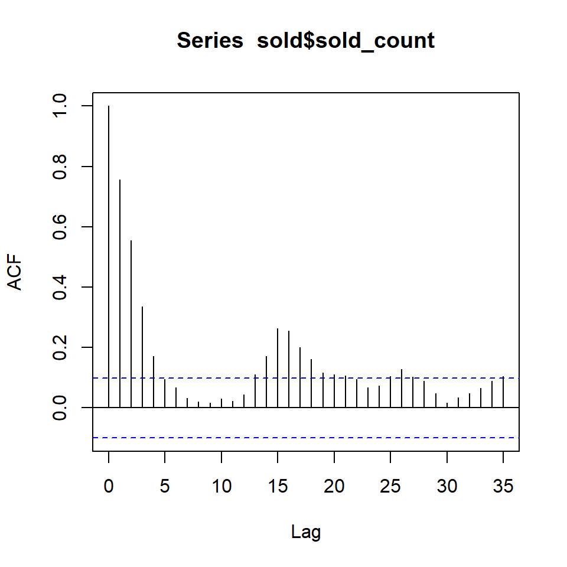

```r
acf(sold$sold_count, lag.max = 35)
```

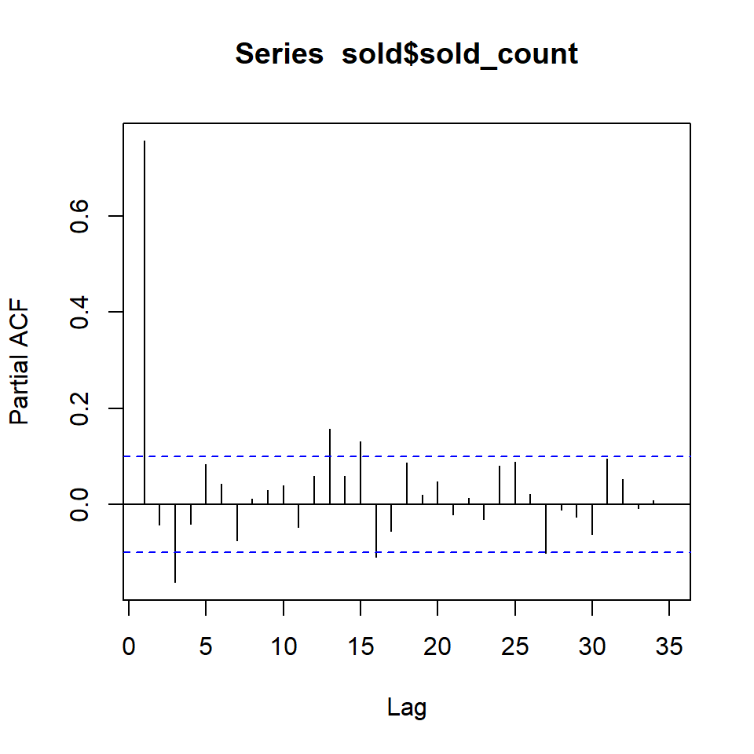

```r
pacf(sold$sold_count, lag.max = 35)
```

From these plots above, we can see that there is seasonality at lag 14. we are going to decompose data with period 7.

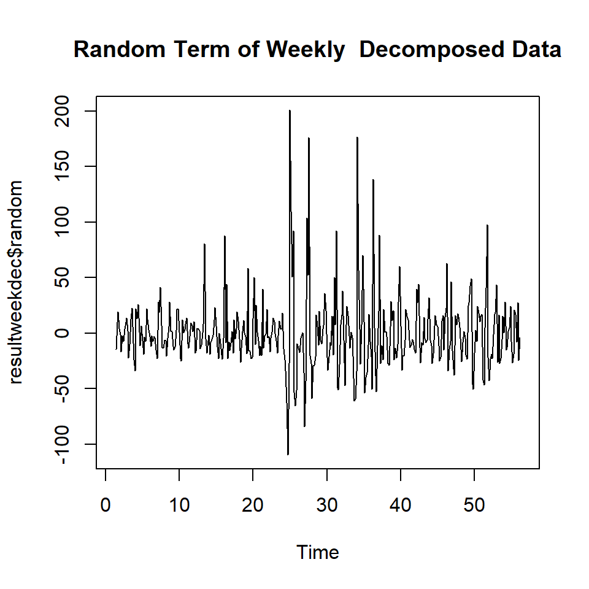

```r
soldts <- ts(rev(pr7$sold_count),  freq = 7, start= c(1,1))
resultweekdec <- decompose(soldts,type= "additive")
plot(resultweekdec$random)
title("Random Term of Weekly  Decomposed Data")
```

```r
random = resultweekdec$random
trend = resultweekdec$trend
season = resultweekdec$seasonal
```

Random term looks like zero mean and constant variance despite some outliers. We can detect these outliers with external regressor later. For now, we continue with this decomposed item to build a ARIMA model. We are going to use AIC values of the models to get the best fitted model. Again before starting using auto.arima() function and neighbour search for the parameters. We will check the ACF and PACF plots of random term.

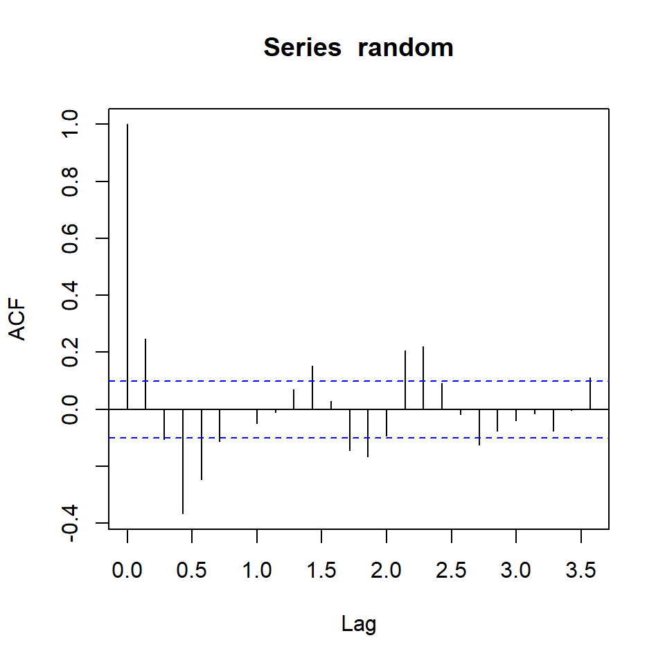

```r
acf(random, na.action = na.pass)
```

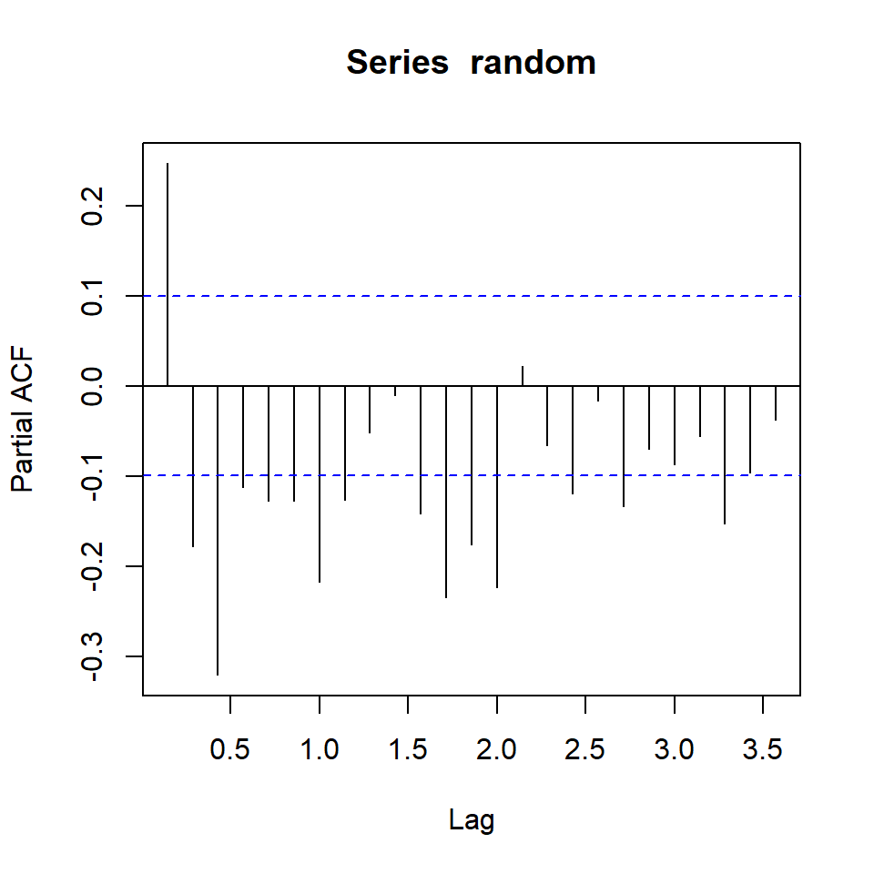

```r
pacf(random, na.action = na.pass)
```

It seems like there should be Moving Average terms in the model. To get a concrete results we can check auto.arima() and arima models with pre-decided parameters

```r
model <- arima(random, order= c(1,0,0))
AIC(model)
```

```
## [1] 3743.469
```

```r
model <- arima(random, order= c(2,0,0))
AIC(model)
```

```
## [1] 3733.196
```

```r
model <- arima(random, order= c(3,0,0))
AIC(model)
```

```
## [1] 3693.76
```

```r
model <- arima(random, order= c(4,0,0))
AIC(model)
```

```
## [1] 3691.007
```

```r
model <- arima(random, order= c(5,0,0))
AIC(model)
```

```
## [1] 3686.785
```

```r
model <- arima(random, order= c(6,0,0))
AIC(model)
```

```
## [1] 3682.557
```

```r
model <- arima(random, order= c(1,0,1))
AIC(model)
```

```
## [1] 3741.91
```

```r
model <- arima(random, order= c(2,0,1))
AIC(model)
```

```
## [1] 3616.72
```

```r
model <- arima(random, order= c(3,0,1))
AIC(model)
```

```
## [1] 3607.498
```

```r
model <- arima(random, order= c(4,0,1))
AIC(model)
```

```
## [1] 3608.996
```

```r
model <- arima(random, order= c(2,0,2))
AIC(model)
```

```
## [1] 3712.049
```

```r
model <- arima(random, order= c(1,0,3))
AIC(model)
```

```
## [1] 3627.553
```

```r
model <- auto.arima(random)
AIC(model)
```

```
## [1] 3677.508
```

```r
model <- arima(random, order= c(2,0,4))
AIC(model)
```

```
## [1] 3573.75
```

After searching for the best model with regard to AIC values, we found the best model with 2 auto regressive term and four moving average term.

Here is the fitted and actual values of the ARIMA model:

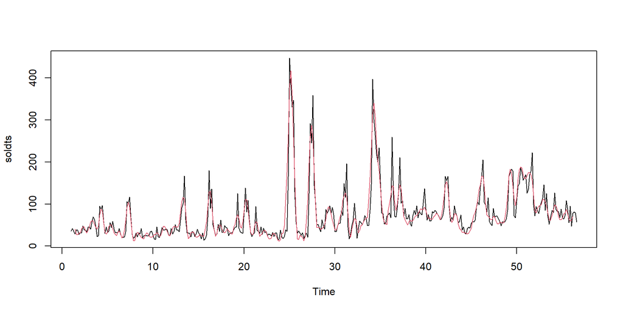

```r
model <- arima(random, order= c(2,0,4)) # final model with respect to AIC values

modelfit <- random - model$residuals
fitted <- modelfit+trend+season

plot(soldts)
points(fitted, type= "l", col = 2)
```

Seems like the model fit well. However at peaks and downs there was still mis-fitted points. To improve the model, we can add external regressors.

We are going to look for variables that might be correlated to sold amount and can be used as regressors in the ARIMAX model. To do this, first I am going to use pairplots. But some of the data in the columns are lost for so many data points. So only columns I can use for this, “Basket Count” , “Category Sold” , Category Visits" and “Category Favored”. I checked the relation of each variable with the sold count.

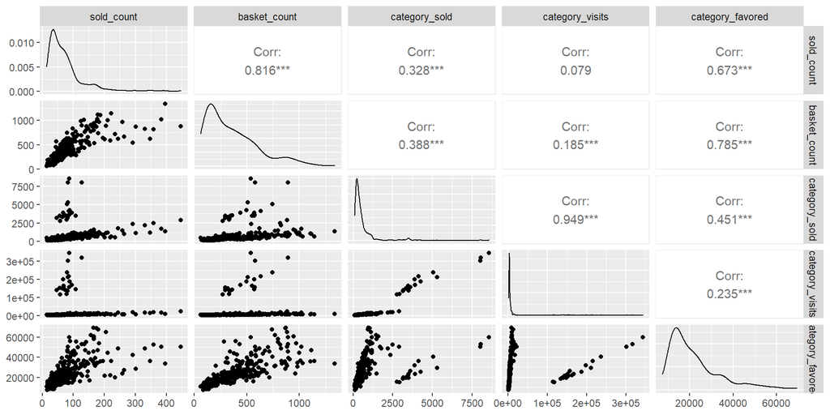

```r
ggpairs(pr7, columns = c(4,7,8,10,13 ))
```

From this plot, Basket Count and Category Favored seems to have a correlation, so I am going to add those variables to the model.

```r
regressors <- pr7[, c(7,13)]
model <- arima(random, order= c(2,0,4), xreg = regressors)
summary(model)
```

```
##
## Call:
## arima(x = random, order = c(2, 0, 4), xreg = regressors)
##
## Coefficients:
##          ar1      ar2      ma1     ma2      ma3     ma4  intercept
##       1.3145  -0.5177  -1.4665  0.2680  -0.1138  0.3125     0.0798
## s.e.  0.0914   0.0889   0.0953  0.1485   0.0998  0.0891     0.0009
##       basket_count  category_favored
##              2e-04                 0
## s.e.         1e-04                 0
##
## sigma^2 estimated as 595.1:  log likelihood = -1777.23,  aic = 3574.45
##
## Training set error measures:
##                     ME     RMSE      MAE       MPE     MAPE      MASE
## Training set 0.3746279 24.39552 15.61669 -1.385579 180.3957 0.6260013
##                     ACF1
## Training set -0.01362434
```

Coefficients of earlier model has been changed, some variables became insignificant. That’s probably because some regressors explains each other. I am going to drop the Category Favored column and some MA terms so to try to fit the model again.

```r
regressors <- pr7$basket_count
model <- arima(random, order= c(2,0,3), xreg = regressors)
summary(model)
```

```
##
## Call:
## arima(x = random, order = c(2, 0, 3), xreg = regressors)
##
## Coefficients:
##          ar1      ar2      ma1     ma2     ma3  intercept  regressors
##       1.4301  -0.6258  -1.5810  0.1946  0.3865     0.0167           0
## s.e.  0.0490   0.0489   0.0484  0.0879  0.0468        NaN         NaN
##
## sigma^2 estimated as 638.1:  log likelihood = -1790.75,  aic = 3597.49
##
## Training set error measures:
##                     ME     RMSE      MAE      MPE     MAPE      MASE
## Training set 0.1314447 25.26124 16.28126 -7.65144 198.0535 0.6526409
##                     ACF1
## Training set -0.04192775
```

Even if I subtract insignificant terms in the model, external regressors still has no signifancy in the model. Therefore, we are going to go with ARIMA model, that we found at the beginning.

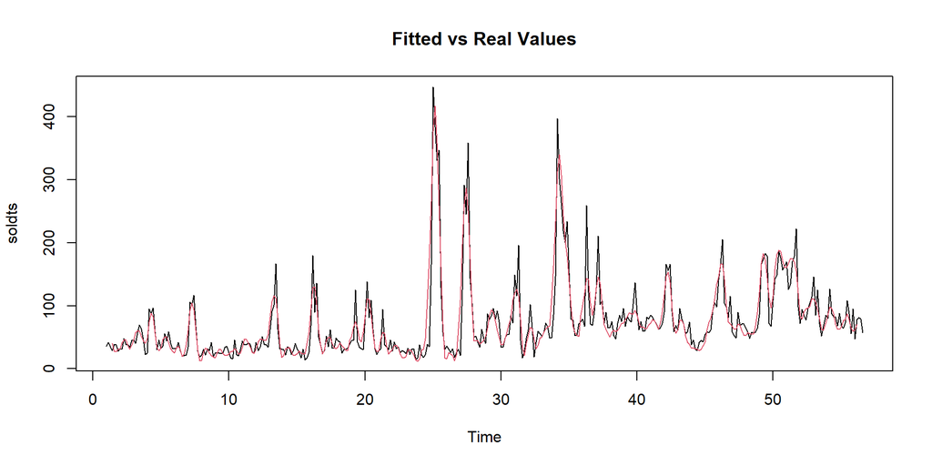

```r
model <- arima(random, order= c(2,0,4))

modelfit <- random - model$residuals
fitted <- modelfit+trend+season

plot(soldts)
points(fitted, type= "l", col = 2)
title("Fitted vs Real Values")
```

For this product, we don’t add the external regressor into model because our first fitted ARIMA model has multiple auto regressive and moving average term. Therefore, external regressors do not affect too much. However, we built in the other products with continuous data ARIMAX model. Comparison and decision between ARIMA, ARIMAX and LM models will be disgust in the Results section.